# Narrowing the brain-publication barrier with R+markdown

Peter Ralph

June 2, 2015

# Markdown

# Just write

**Goal:** don't even *think* about the layout, just the content.

**Solutions:**

- unformatted text
- [markdown](http://commonmark.org/)
- [LaTeX](http://latex-project.org/intro.html)

Markdown aims to be readable as-is, but *also* have methods to produce beautiful output.

> A Markdown-formatted document should be publishable as-is, as plain text, without looking like it's been marked up with tags or formatting instructions. -- [John Gruber](http://daringfireball.net/projects/markdown/syntax#philosophy)

# No, really, don't think about the layout

Don't even *think* about the layout, just the content.

> [...] it is better to leave document design to document designers, and to let authors get on with writing documents -- [intro to LaTeX](http://latex-project.org/intro.html)

Today's goal:

1. Learn a few simple rules
2. and get going producing content.

# Structuring text

1. Separate things with empty lines.
2. Wrap lines whenever you feel like it.

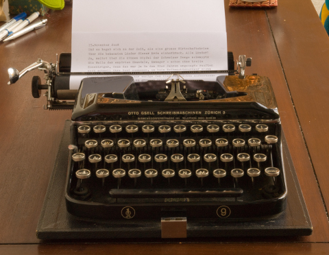

your laptop?

# Source

```markdown
Text formatting
===============

Inline markup
-------------

**Paragraphs** begin and end with empty lines,
and are *not* indented.

- **bold** and *emphasis*
- ~~strikeout~~
- super^scripts^ and sub~scripts~
- and `inline_code($fixed.width)`
```

# Result

### Text formatting

#### Inline markup

**Paragraphs** begin and end with empty lines, and are *not* indented.

- **bold** and *emphasis*
- strikeout
- super<sup>scripts</sup> and sub<sub>scripts</sub>
- and `inline_code($fixed.width)`

# Source

```markdown
Lists must be preceded by an empty line,

1.  ordered or unordered.
2.  Indenting subsequent content

    -  will continue the list

        *   and nest
        *   other lists.

3.  *Indenting* means one tab, or four spaces.

After using markdown for a bit,
go read [pandoc's documentation](http://pandoc.org/README.html).
```

Lists must be preceded by an empty line,

1. ordered or unordered.
2. Indenting subsequent content
   - will continue the list
     - and nest
     - other lists.
3. *Indenting* means one tab, or four spaces.

After using markdown for a bit, go read [pandoc's documentation](http://pandoc.org/README.html).

# Math

```
Math goes between `$`, single ($\pi$), or double:
$$ \frac{\pi}{4} = \sum_{n=0}^\infty \frac{(-1)^n}{2k+1} .$$
```

Math goes between `$`, single ($\pi$), or double:
$$\frac{\pi}{4} = \sum_{n=0}^\infty \frac{(-1)^n}{2k+1} .$$

Even math environments *inside* double dollar signs:

```markdown
$$
\begin{align}
    x &= (a+b)^2 - (a-b)^2 \\
      &= 4ab
\end{align}
$$
```

\begin{align} x &= (a+b)^2 - (a-b)^2 \\ &= 4ab \end{align}

# Code blocks

````
```{.r}
msg <- "Hello, world."
print(msg)
```
````

**produces**

```r
msg <- "Hello, world."
print(msg)
```

# Blockquotes

```
> I also dream about a modern replacement for LaTeX
> designed from the ground up to target multiple output formats
> (at least PDF, HTML, EPUB). -- [John MacFarlane](http://john.macfarlane.usesthis.com/)
```

**produces**

> I also dream about a modern replacement for LaTeX designed from the ground up to target multiple output formats (at least PDF, HTML, EPUB). -- [John MacFarlane](http://john.macfarlane.usesthis.com/)

# Links and Images

[Links](http://www.w3.org/) just go in parentheses, and can be internal.

```markdown
[Links](http://www.w3.org/) just go in parentheses,
and can be [internal](#links-and-images).
```

Images are **the same** but with a `!` in front.  
(You can't specify image size in the markdown, [yet](https://github.com/jgm/pandoc/issues/261#issuecomment-101078069).)

```markdown
![oh, internet](cat-pandoc.jpg)
```

[figure not shown]

oh, internet

# Rendering markdown with [pandoc](http://pandoc.org)

# Get started!

0. Make a directory for this workshop.
1. Open a text editor.
2. Write something.
3. Save it as `notes.md`.

To compile, either:

- Open `R`, run

  ```r
  library(knitr)
  knit2html("notes.md")
  ```

  and open `notes.html` in your web browser.
- **or** click on *knit* in `Rstudio`

# Wait, but the layout?

Remember,

> [...] it is better to leave document design to document designers, and to let authors get on with writing documents.

If you **must**, then:

- tweak the css
- modify a [rmarkdown format](http://rmarkdown.rstudio.com/developer_custom_formats.html)
- or a [pandoc template](http://pandoc.org/README.html#templates)

# Gotchas

1. many things need to begin with an empty line
2. carriage returns don't (usually) mean anything
3. but indentations do (*by at least four spaces*)

To separate two numbered lists, add a non-indented, invisible element, like an html comment:

```html
<!-- -->
```

For more info see [the documentation](http://pandoc.org/README.html#the-four-space-rule).

# Metadata

At the top of your document, add

```yaml
---
title: YOUR TITLE HERE
author: YOUR NAME HERE
date: June 2, 2015
---
```

... the [YAML](http://yaml.org/) metadata,  
delimited by **exactly three** dashes.

**Note:** Besides setting the title, you can control the **output** in [many](http://tex.stackexchange.com/questions/139139/adding-headers-and-footers-using-pandoc/139205#139205) [ways](http://rmarkdown.rstudio.com/html_document_format.html#pandoc-arguments) here.

*For example*: add

```yaml
output_format : pdf_document
```

and render with `rmarkdown::render("notes.md")`.

# Under the hood

[`pandoc`](http://pandoc.org/README.html)

```bash
pandoc --help
```

# Adding in R

**Goal:** add R code to the document, *along with its output*.

[figure not shown]

knitr

# Go ahead

Just add a *chunk* of R code, wrapped in

````
 ```{r}
 # PUT ARBITRARY R CODE HERE
 ```
````

**Try it!**

````
 ```{r}
 cumsum( -4 * (-1)^(1:20) / (2*(1:20)-1) )
 ```
````

**produces**

```r
cumsum( -4 * (-1)^(1:20) / (2*(1:20)-1) )
```

```
##  [1] 4.000000 2.666667 3.466667 2.895238 3.339683 2.976046 3.283738
##  [8] 3.017072 3.252366 3.041840 3.232316 3.058403 3.218403 3.070255
## [15] 3.208186 3.079153 3.200366 3.086080 3.194188 3.091624
```

````
 ```{r}
 plot(cumsum( -4 * (-1)^(1:20) / (2*(1:20)-1) ))
 abline(h=pi, col='red')
 ```
````

**produces**

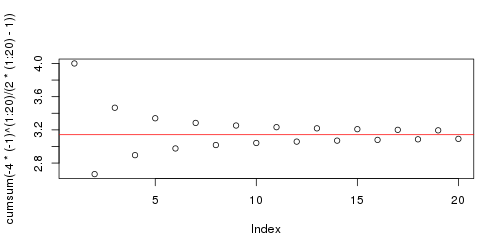

```r
plot(cumsum( -4 * (-1)^(1:20) / (2*(1:20)-1) ))
abline(h=pi, col='red')
```

# Show only the results:

````
 ```{r, echo=FALSE}
 plot(cumsum( -4 * (-1)^(1:20) / (2*(1:20)-1) ))
 abline(h=pi, col='red')
 ```
````

**produces**

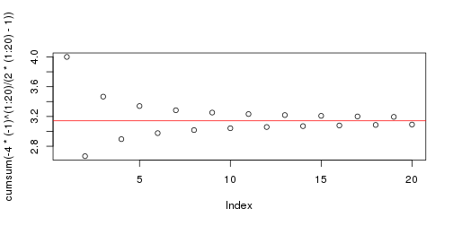

# What's going on

1. `knitr` uses a *regular expression* to find code chunks
   - pulls these out,
   - evaluates them one at a time
   - and inserts "the results" back in
2. `pandoc` renders the resulting markdown file
   - with various choices of styling

# Chunk options

Name each chunk, and set [options](http://yihui.name/knitr/options/) for [what gets printed](http://yihui.name/knitr/demo/output/)

````
 ```{r my_chunk_name, fig.height=4, echo=FALSE}
````

**`echo=(TRUE|FALSE)`**

include source code in the output?

**`results="(markup|asis)"`**

style the output or not?

**`include=(FALSE|TRUE)`**

include anything in the output?

Set document defaults up top:

````
 ```{r, include=FALSE}
 fig.dim <- 5
 library(knitr)
 opts_chunk$set(
        fig.height=fig.dim,
        fig.width=2*fig.dim,
        fig.align='center'
    )
 ```
````

# Tables

One option: use `pander` + `results="asis"`.

````
 ```{r results="asis"}
 library(pander)
 bases <- table( sample( c("A","C","G","T"), 300, replace=TRUE ) )
 pander(t(bases))
 ```
````

*note:* the transpose `t( )`

```r
 library(pander)
 bases <- table( sample( c("A","C","G","T"), 300, replace=TRUE ) )
 pander(t(bases))
```

| A | C | G | T |
| --- | --- | --- | --- |
| 76 | 78 | 77 | 69 |

# R everywhere

```
You can
`r paste(letters[c(9,14,19,5,18,20)],collapse='')`
code anywhere.
```

You can insert code anywhere.

Even in the YAML header.

Go change yours!

```
---
title: My notes
author: Peter Ralph
date: `r date()`
---
```

# Online example

**Question:** How accurate is inference of the slope of a linear regression, as a function of the sample size?

Let's figure it out, by simulation.

# Your turn

Download the [iris dataset](https://raw.githubusercontent.com/petrelharp/r-markdown-tutorial/master/examples/iris.tsv) to a new directory.

or just do

```r
data(iris)
write.table(iris,file="examples/iris.tsv",sep="\t")
```

1. Read in the data.
2. Describe the dataset: number of observations, variables, etcetera.
   - inline `R` code (`` `r nrow(data)` ``)
3. Make a table of the number of observations for each species.
   - `results="asis"` and `pander()`
4. Plot the flower dimensions against each other,
   - first using `pairs()`, then
   - colored by species.

# Templated reports

**Do this** to set up some fake data:

```r
dir.create("examples/thedata")
owd <- setwd("examples/thedata")
for (samp in LETTERS[1:10]) {
    xy <- data.frame(
        age=exp(rnorm(50)),
        type=sample(letters[1:3],50,replace=TRUE)
    )
    xy$height <- 5 + runif(1)*xy$age + 3*runif(1)*as.numeric(xy$type) + rnorm(50)
    write.table(xy,file=paste(samp,"-data.tsv",sep=''))
}
setwd(owd)
```

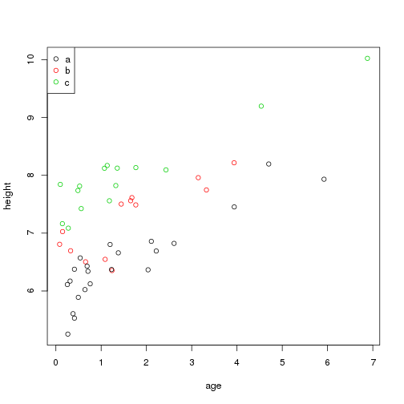

**The template:** `examples/simple-template.Rmd`

````
 ---
 title: Visualization for `r input.file`
 date: `r date()`
 ---

 ```{r, echo=FALSE}
 xy <- read.table(input.file)
 ```

 The file `r input.file`
 has `r nrow(xy)` observations:

 ```{r}
 plot( height ~ age, col=type, data=xy )
 legend( "topleft", pch=1, col=1:nlevels(xy$type),
    col=1:nlevels(xy$type) )
 ```
````

**Render it:**

```r
library(knitr)
owd <- setwd("examples/thedata")  # determines where output will go
opts_knit$set(root.dir=".")  # determines where code is evaluated
file.names <- list.files(".",".*tsv")
for (input.file in file.names) {
    output.file <- gsub(".tsv$",".viz.html",input.file)
    knit2html("../simple-template.Rmd", output=output.file, quiet=TRUE)
}
setwd(owd)
```

**Look at them:**

````
 ```{r make_links, results="asis"}
 output.files <- file.path("examples/thedata",gsub(".tsv$",".viz.html",file.names))
 links <- paste("[",file.names,"](",output.files,")",sep='')
 cat( paste("- ", links, "\n"), "\n" )
 ```
````

- A-data.tsv
- B-data.tsv
- C-data.tsv
- D-data.tsv
- E-data.tsv
- F-data.tsv
- G-data.tsv
- H-data.tsv
- I-data.tsv
- J-data.tsv

# Other resources

- my technical notes I made while writing this up
- [Karl Broman's](http://kbroman.org/knitr_knutshell/pages/Rmarkdown.html) intro to Rmarkdown
- the extensive, excellent [documentation for pandoc](http://pandoc.org/README.html)
- [StackOverflow](http://stackoverflow.com/)